V

Interactive map

# Vancouver Property Tax & Civic Real Estate Explorer

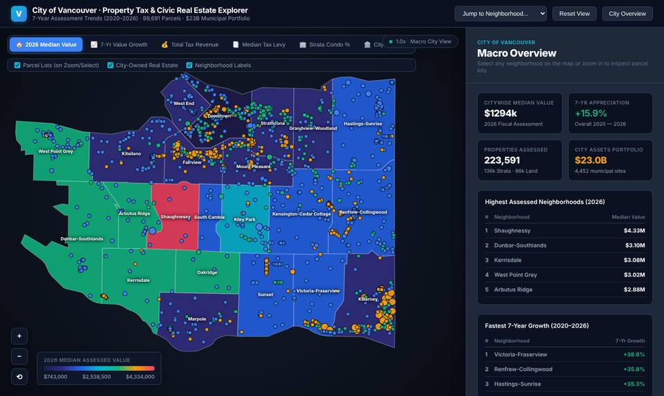

An interactive map of Vancouver property assessments from 2020 to 2026. Neighbourhoods are coloured by value, growth or tax levy, and you can zoom in to individual lots and city-owned sites.

🖥️

**Best viewed on a larger screen** The map and its detail panels need room. Open this page on a laptop, desktop or tablet for the full experience.

- **22 neighbourhoods** compared on median value, 7-year growth, tax revenue and condo share
- **Individual parcel lots** appear as you zoom into a neighbourhood
- **City-owned properties** are marked on the map and summarised in the side panel

It will work, but the controls are small and crowded on a phone.

Built from City of Vancouver Open Data property tax, parcel and city-owned property datasets.

V

# City of Vancouver · Property Tax & Civic Real Estate Explorer

7-Year Assessment Trends (2020–2026) · 99,691 Parcels · $23B Municipal Portfolio

Parcel Lots (on Zoom/Select) City-Owned Real Estate Neighborhood Labels

1.0x · Macro City View

2026 Median Assessed Value

Kitsilano

$1,284,000

15,056 properties · +23.0% 7-Yr Growth